## Estudo sobre Faturamento x Atendimento por Prestador

#### Preparação do ambiente

Bibliotecas utilizadas, código abaixo (oculto, utilize o botão a direita para expor).

```r
## Opções iniciais de configuração do ambiente --------------
knitr::opts_chunk$set(echo = TRUE)
options(scipen=999)
#### --------------------------------------------------------
library("stringr", lib.loc="~/R/win-library/3.4")
library("dplyr", lib.loc="~/R/win-library/3.4")
library("ggplot2", lib.loc="~/R/win-library/3.4")
library("readr", lib.loc="~/R/win-library/3.4")
library("tibble", lib.loc="~/R/win-library/3.4")
library("tidyr", lib.loc="~/R/win-library/3.4")
library("magrittr", lib.loc="~/R/win-library/3.4")
library("readxl", lib.loc="~/R/win-library/3.4")
library("purrr", lib.loc="~/R/win-library/3.4")
#### --------------------------------------------------------
```

### Processo de cálculo automatizado de indicadores

Para separação dos seguintes grupos:

**FTT - Valor/Qt de Faturamento total** (Soma de linhas de faturamento para referência)  
**FCR - Valor/Qt de Faturamento corrente** (Referencia de faturamento = Referência de atendimento)  
**FAC - Valor/Qt de Faturamento acumulado** (Referência de faturamento <> Referência de atendimento)  
**FMA - Valor/Qt de Faturamento do mês anterior** (Referência do faturamento = Referência do mês anterior de atendimento)  
**ATE - Valor/Qt de Atendimento total** (Soma de linhas de atendimento para referência)

```r
##----------------------------------------------------------------------------
##----------------------------------------------------------------------------
  v.top <- 20
  v.limite_min <- 35*1000*1000
##----------------------------------------------------------------------------
##----------------------------------------------------------------------------

x_anomes_id <- read_excel('anomes_id.xlsx') %>% mutate(anomes = factor(anomes))
x_fat_ate_d <- read_excel('Geral2014_17_prestadores_d.xlsx')
x_geral_d <- read_excel('Geral2014_17_d.xlsx')

print(paste0('Representatividade dos 200 maiores prestadores no faturamento total (2014-2017/07): ', round((((sum(x_fat_ate_d$VA)+sum(x_fat_ate_d$VR))/(sum(x_geral_d$VA)+sum(x_geral_d$VR)))*100), 2), '%   '))
```

```
## [1] "Representatividade dos 200 maiores prestadores no faturamento total (2014-2017/07): 84.08%   "
```

```r
print(paste0('Parâmetro de seleção de prestadores (top N): ', v.top, '    '))
```

```
## [1] "Parâmetro de seleção de prestadores (top N): 20    "
```

```r
print(paste0('Parâmetro de Valor mínimo de faturamento acumulado total: ', v.limite_min, '    '))
```

```
## [1] "Parâmetro de Valor mínimo de faturamento acumulado total: 35000000    "
```

```r
##----------------------------------------------------------------------------
## Por prestador
##----------------------------------------------------------------------------

x_fat_ate_d %<>%
  merge(.,x_anomes_id, by.x = 'ANOMES_FT', by.y = 'anomes') %>%
  merge(.,x_anomes_id, by.x = 'ANOMES_AT', by.y = 'anomes') %>%
  arrange(CODIGO, id.x, id.y) %>%
  mutate(DELTA_ANM = id.x-id.y, CT = 1) %>%
  select(CODIGO, PRESTADOR,
         ANOMES_FT,
         DELTA_ANM,
         ID_FT = id.x,
         ANOMES_AT,
         ID_AT = id.y,
         QP, VA, VR, CT)


f.shuffle_p <- function(df, FT_AT = df$ANOMES_FT, mrge = 'N') {
  df %<>% group_by(CODIGO, PRESTADOR, ANOMES = FT_AT) %>%
    dplyr::summarise(sum(QP, na.rm = T),
                     sum(VA, na.rm = T),
                     sum(VR, na.rm = T),
                     sum(CT, na.rm = T))

  if (mrge == 'A') {
    df %<>% merge(FA.df_base, ., by = c('CODIGO', 'PRESTADOR', 'ANOMES'), all = T)
  } else if (mrge == 'X') {
    df %<>% merge(FA.df_base, ., by = c('CODIGO', 'PRESTADOR', 'ANOMES'), all.x = T)
  }

  return(df)
}

FA.df_base <- x_fat_ate_d %>%
  f.shuffle_p() %>%
  as.data.frame()

FA.df_base <- x_fat_ate_d %>%
  filter(DELTA_ANM == 0) %>%
  f.shuffle_p(mrge = 'A')

FA.df_base <- x_fat_ate_d %>%
  filter(DELTA_ANM != 0) %>%
  f.shuffle_p(mrge = 'A')

FA.df_base <- x_fat_ate_d %>%
  filter(DELTA_ANM == 1) %>%
  f.shuffle_p(mrge = 'A')

FA.df_base <- x_fat_ate_d %>%
  f.shuffle_p(FT_AT = .$ANOMES_AT, mrge = 'X')

FA.df_base[is.na(FA.df_base)] <- 0

names(FA.df_base) <- c('CODIGO', 'PRESTADOR', 'ANOMES',
                       'QTA_FTT', 'VA_FTT', 'VR_FTT', 'C_FTT',
                       'QTA_FCR', 'VA_FCR', 'VR_FCR', 'C_FCR',
                       'QTA_FAC', 'VA_FAC', 'VR_FAC', 'C_FAC',
                       'QTA_FMA', 'VA_FMA', 'VR_FMA', 'C_FMA',
                       'QTA_ATE', 'VA_ATE', 'VR_ATE', 'C_ATE')

FA.df_base %<>% select(CODIGO, PRESTADOR, ANOMES,
                       VA_FTT, VA_ATE, VA_FCR, VA_FAC, VA_FMA,
                       # QTA_FTT, QTA_ATE, QTA_FCR, QTA_FAC, QTA_FMA,
                       VR_FTT, VR_ATE, VR_FCR, VR_FAC, VR_FMA,
                       C_FTT, C_ATE #, C_FCR, C_FAC, C_FMA
                       ) %>%
  mutate(P_FCR = VA_FCR/VA_FTT,
         P_FMA = VA_FMA/VA_FTT,
         DIF = VA_FTT-VA_ATE,
         ANOMES = factor(ANOMES),
         ANO = str_sub(ANOMES, 1, 4))

##----------------------------------------------------------------------------
## Geral
##----------------------------------------------------------------------------

x_geral_d %<>%
  merge(.,x_anomes_id, by.x = 'ANOMES_FT', by.y = 'anomes') %>%
  merge(.,x_anomes_id, by.x = 'ANOMES_AT', by.y = 'anomes') %>%
  arrange(id.x, id.y) %>%
  mutate(DELTA_ANM = id.x-id.y, CT = 1) %>%
  select(ANOMES_FT,
         DELTA_ANM,
         ID_FT = id.x,
         ANOMES_AT,
         ID_AT = id.y,
         QP, VA, VR, CT)

f.shuffle <- function(df, FT_AT = df$ANOMES_FT, mrge = 'N')  {
  df %<>% group_by(ANOMES = FT_AT) %>%
    dplyr::summarise(sum(QP, na.rm = T),
                     sum(VA, na.rm = T),
                     sum(VR, na.rm = T),
                     sum(CT, na.rm = T))

  if (mrge == 'A') {
    df %<>% merge(FA.df_base_geral, ., by = 'ANOMES', all = T)
  } else if (mrge == 'X') {
    df %<>% merge(FA.df_base_geral, ., by = 'ANOMES', all.x = T)
  }

  return(df)
}

FA.df_base_geral <- x_geral_d %>%
  f.shuffle() %>%
  as.data.frame()

FA.df_base_geral <- x_geral_d %>%
  filter(DELTA_ANM == 0) %>%
  f.shuffle(mrge = 'A')

FA.df_base_geral <- x_geral_d %>%
  filter(DELTA_ANM != 0) %>%
  f.shuffle(mrge = 'A')

FA.df_base_geral <- x_geral_d %>%
  filter(DELTA_ANM == 1) %>%
  f.shuffle(mrge = 'A')

FA.df_base_geral <- x_geral_d %>%
  f.shuffle(FT_AT = .$ANOMES_AT, mrge = 'X')

FA.df_base_geral[is.na(FA.df_base_geral)] <- 0

names(FA.df_base_geral) <- c('ANOMES',
                       'QTA_FTT', 'VA_FTT', 'VR_FTT', 'C_FTT',
                       'QTA_FCR', 'VA_FCR', 'VR_FCR', 'C_FCR',
                       'QTA_FAC', 'VA_FAC', 'VR_FAC', 'C_FAC',
                       'QTA_FMA', 'VA_FMA', 'VR_FMA', 'C_FMA',
                       'QTA_ATE', 'VA_ATE', 'VR_ATE', 'C_ATE')

FA.df_base_geral %<>% select(ANOMES,
                             VA_FTT, VA_ATE, VA_FCR, VA_FAC, VA_FMA,
                             # QTA_FTT, QTA_ATE, QTA_FCR, QTA_FAC, QTA_FMA,
                             VR_FTT, VR_ATE, VR_FCR, VR_FAC, VR_FMA,
                             C_FTT, C_ATE #, C_FCR, C_FAC, C_FMA
                             ) %>%
  mutate(P_FCR = VA_FCR/VA_FTT,
         P_FMA = VA_FMA/VA_FTT,
         DIF = VA_FTT-VA_ATE,
         ANOMES = factor(ANOMES),
         ANO = str_sub(ANOMES, 1, 4))
```

### Cálculo de dados padronizados

Planilha original importada e resultado final com dados padronizados, por prestador.

```r
sf <- factor(FA.df_base$CODIGO)

FA.df_base %<>%
  split(sf, drop = T) %>%
  map(~cbind(., escala = scale(.$DIF, F, T))) %>%
  unsplit(sf)

FA.df_base_geral %<>% cbind(.,escala_geral = scale(.$DIF, F, T))

FA.df_base %<>%  add_column(., escala_geral = FA.df_base_geral[match(.$ANOMES, FA.df_base_geral$ANOMES), 18])

##----------------------------------------------------------------------------
write.csv2(FA.df_base, 'Prestador_FT_AT_Anomes_d.csv')
##----------------------------------------------------------------------------
write.csv2(FA.df_base_geral, 'Geral_FT_AT_Anomes_d.csv')
##----------------------------------------------------------------------------
```

### Calculo de saldo anual de valor atentdido

```r
FA.saldo_ate <-  FA.df_base %>%
  group_by(CODIGO, PRESTADOR, ANO) %>%
  summarise(SALDO = sum(DIF*(-1), na.rm = T),
            FATURAMENTO = sum(VA_FTT, na.rm = T),
            P_SF = round(((sum(DIF*(-1), na.rm = T))/sum(VA_FTT, na.rm = T))*100, 2)) %>%
  as.data.frame()
```

### Geração de rankings

Conteúdo do arquivo gerado:

[output not shown]

```r
f.sum_rank <- function(df) {
  res <- vector()
  res[1] <- sum(df$VA_FTT, na.rm = T) + sum(df$VR_FTT, na.rm = T)
  res[2] <- mad(df$escala, na.rm = T)
  res[3] <- mean(abs(df$escala), na.rm = T)
  res[4] <- mean(df$P_FCR, na.rm = T)
  names(res) <- c('VT', 'DM', 'VM', 'FC')
  return(res)
}

FA.lst_rank <- FA.df_base %>%
  split(.$CODIGO, drop = T) %>%
  map(f.sum_rank)

FA.df_rank <- tibble(prestador = character(),
                     nome = character(),
                     faturado.r = integer(),
                     faturado = double(),
                     dma.r = integer(),
                     dma = double(),
                     dma.c.r = integer(),
                     dma.c = double(),
                     fcr.r = integer(),
                     fcr = integer(),
                     isa.r = double(),
                     isa = double())

for (i in seq_along(FA.lst_rank)) {
  FA.df_rank[i,] <- c(names(FA.lst_rank)[[i]],
                      '-',
                      0,
                      FA.lst_rank[[i]]['VT'],
                      0,
                      FA.lst_rank[[i]]['DM'],
                      0,
                      FA.lst_rank[[i]]['VM'],
                      0,
                      FA.lst_rank[[i]]['FC'],
                      0,
                      0)
}

FA.df_rank %<>% mutate(faturado = as.double(faturado),
                      dma = round(as.double(dma), 2),
                      dma.c = as.double(dma.c),
                      fcr = round(as.double(fcr)*100, 2),
                      nome = FA.df_base[match(.$prestador,FA.df_base$CODIGO), 2],
                      isa = FA.saldo_ate[match(paste0(.$prestador,'2017'),
                                               paste0(FA.saldo_ate$CODIGO,
                                                      FA.saldo_ate$ANO)), 6]) %>%
  arrange(desc(faturado)) %>%
  mutate(faturado.r = 1:dim(FA.df_rank)[1]) %>%
  arrange(desc(dma)) %>%
  mutate(dma.r = 1:dim(FA.df_rank)[1]) %>%
  arrange(desc(dma.c)) %>%
  mutate(dma.c.r = 1:dim(FA.df_rank)[1]) %>%
  arrange(fcr) %>%
  mutate(fcr.r = 1:dim(FA.df_rank)[1]) %>%
  arrange(isa) %>%
  mutate(isa.r = 1:dim(FA.df_rank)[1])

##----------------------------------------------------------------------------
write.csv2(FA.df_rank, 'Prestador_ranking.csv')
##----------------------------------------------------------------------------
##FA.df_rank
```

### Preparação de tabela resumo e gráficos

Para dados padronizados Planserv x Prestador, código oculto abaixo.

```r
FA.lst_prestador <- FA.df_base %>%
  split(.$CODIGO)

v.meses <- FA.df_base_geral %>%
  filter(ANO == max(ANO)) %>%
  tally() %>%
  '[['(1) %>%
  as.integer()

f.tb_param <- function(nm, i) {
  print(FA.lst_prestador[[nm]][[1,'PRESTADOR']])
  print('------------------------------------------------------------------')
  print(paste0('Raking da seleção                : ',
               str_pad(i, width = 3, side="left", pad = ' '), '    '))
##----------------------------------------------------------------------------
  print(paste0('Raking de faturamento            : ',
               str_pad(FA.df_rank[FA.df_rank$prestador == FA.lst_prestador[[nm]][[1,'CODIGO']],'faturado.r'],
               width = 3, side="left", pad = ' '), '    '))
##----------------------------------------------------------------------------
  print(paste0('Raking de desvio médio absoluto  : ',
               str_pad(FA.df_rank[FA.df_rank$prestador == FA.lst_prestador[[nm]][[1,'CODIGO']],'dma.r'],
               width = 3, side="left", pad = ' '), '    '))
##----------------------------------------------------------------------------
  print(paste0('Raking de % médio de f. corrente : ',
               str_pad(FA.df_rank[FA.df_rank$prestador == FA.lst_prestador[[nm]][[1,'CODIGO']],'fcr.r'],
               width = 3, side="left", pad = ' '), '    '))
##----------------------------------------------------------------------------
  print(paste0('Raking de % saldo de atendimento : ',
               str_pad(FA.df_rank[FA.df_rank$prestador == FA.lst_prestador[[nm]][[1,'CODIGO']],'isa.r'],
               width = 3, side="left", pad = ' '), '    '))
  print('------------------------------------------------------------------')
  print(paste0('Faturamento total                : ',
               str_pad(FA.df_rank[FA.df_rank$prestador == FA.lst_prestador[[nm]][[1,'CODIGO']],'faturado'],
               width = 20, side="right", pad = ' ')))
##----------------------------------------------------------------------------
  print(paste0('Desvio médio absoluto            : ',
               str_pad(FA.df_rank[FA.df_rank$prestador == FA.lst_prestador[[nm]][[1,'CODIGO']],'dma'],
               width = 20, side="right", pad = ' ')))
##----------------------------------------------------------------------------
  print(paste0(' % Médio de faturamento corrente : ',
               str_pad(FA.df_rank[FA.df_rank$prestador == FA.lst_prestador[[nm]][[1,'CODIGO']],'fcr'],
               width = 20, side="right", pad = ' ')))
##----------------------------------------------------------------------------
  print(paste0(' % Limite de acumulado 2017      : ',
               str_pad(round((1/v.meses)*(100-FA.df_rank[FA.df_rank$prestador == FA.lst_prestador[[nm]][[1,'CODIGO']],'fcr']), 2),
               width = 20, side="right", pad = ' ')))
  print('------------------------------------------------------------------')

  tsld <- FA.saldo_ate %>%
    filter(CODIGO == nm) %>%
    arrange(desc(ANO)) %>%
    select('|Ano|' = ANO,
           '|Saldo|' = SALDO,
           '|Faturamento Anual|' = FATURAMENTO,
           '|% Saldo sobre Faturamento|' = P_SF) %>%
    print()
  print('------------------------------------------------------------------')

  tbp <- FA.lst_prestador[[nm]] %>%
    mutate(VA_FTT = round(VA_FTT, 0),
           VA_ATE = round(VA_ATE, 0),
           P_FCR = round((P_FCR*100), 2)) %>%
    select ('|Ano e mês|' = ANOMES,
            '|V. Faturado|' = VA_FTT,
            '|V. Atendido|' = VA_ATE,
            '|% F.Corrente|' = P_FCR,
            '|Qt.Rf.Fat.|' = C_FTT) %>%
    as.data.frame()

  #print(tbp)
}

f.gg_param <- function(nm) {

  v.gt <- which(FA.lst_prestador[[nm]][,'ANOMES'] == '201705')

  ggp <- ggplot(data = FA.lst_prestador[[nm]], aes(x = ANOMES, y = escala_geral)) +
    geom_linerange(aes(ymax = ifelse(escala > escala_geral, escala, escala_geral),
                       ymin = ifelse(escala <= escala_geral, escala, escala_geral),
                       col = (escala_geral-escala)),
                   size = 1.2, alpha = 0.3) +
    geom_point(aes(y = escala, col = (escala_geral-escala)),
               size = 4, alpha = 1) +
    geom_point(col = 'red', size = 1.7, alpha = 0.5, shape = 15) +
    geom_line(aes(y = (P_FCR)+4), col = 'blue', size = 0.8, alpha = 0.4, group = 1) +
    geom_hline(yintercept = 0, col = 'black', alpha = 0.4) +
    geom_hline(yintercept = 5, col = 'green', alpha = 0.7) +
    geom_hline(yintercept = 4.5, col = 'black', alpha = 0.7) +
    geom_hline(yintercept = 4, col = 'red', alpha = 0.7) +
    geom_label(aes(x = 1, y = 5.3, label = '% Faturamento Corrente'),
               col = 'blue', hjust = 'left', alpha = 0.8) +
    geom_vline(xintercept = v.gt, col = 'red', size = 1, alpha = 0.6) +
    geom_label(aes(x = v.gt-0.2, y = 3, label = 'Gestão de teto >'),
               col = 'red', hjust = 'right', alpha = 0.8) +
    scale_y_continuous(breaks = seq(-7, 7, by = 0.5)) +
    scale_colour_gradient2(name='Delta para\nEscala Geral',
                           high = 'dark green',
                           mid = 'light blue',
                           low = 'red',
                           midpoint = 0) +
    labs(title = paste0('Proporção do Delta Faturamento x Atendimento Padronizada\n',
                        FA.lst_prestador[[nm]][[1,'PRESTADOR']]),
         x = 'Ano e Mês',
         y = 'Desvios Padrão') +
    theme_bw() +
    theme(axis.text.x = element_text(angle = 45,
                                     vjust = 1,
                                     size = 9,
                                     hjust = 1))

  plot(ggp)
}

f.gg_fa <- function(nm) {

  v.gt <- which(FA.lst_prestador[[nm]][,'ANOMES'] == '201705')

  df <- FA.lst_prestador[[nm]] %>%
    select(ANOMES,
          PRESTADOR,
          'Valor Faturado' = VA_FTT,
          'Valor Atendido' = VA_ATE) %>%
    gather(-ANOMES,
          -PRESTADOR,
          key = 'Indicador', value = 'Valor')

  ggp <- ggplot(data = df, aes(x = ANOMES)) +
    geom_line(aes(y = (Valor)/1000, col = Indicador, group = Indicador),
              size = 0.9, alpha = 0.9) +
    geom_vline(xintercept = v.gt, col = 'dark green', size = 1, alpha = 0.6) +
    geom_label(aes(x = v.gt-0.2, y = 0, label = 'Gestão de teto >'),
               col = 'dark green', hjust = 'right', alpha = 0.8) +
    scale_y_continuous(breaks = seq(0, 100000, by = 500)) +
    scale_colour_manual(values = c("#CC3300", "#660099")) +
    labs(title = paste0('Valores de Faturamento e Atendimento\n',
                        df[[1,'PRESTADOR']]),
         x = 'Ano e Mês',
         y = 'Valores em Milhares') +
    theme_linedraw() +
    theme(axis.text.x = element_text(angle = 45,
                                     vjust = 1,
                                     size = 9,
                                     hjust = 1))

  plot(ggp)

  df <- FA.lst_prestador[[nm]] %>%
    mutate(VA_FOM = VA_FTT-(VA_FCR+VA_FMA)) %>%
    select(ANOMES,
          PRESTADOR,
          '3-Corrente' = VA_FCR,
          '2-Ref. Anterior' = VA_FMA,
          '1-Outras refs.' = VA_FOM) %>%
    gather(-ANOMES,
          -PRESTADOR,
          key = 'Indicador', value = 'Valor')

  ggb <- ggplot(data = df, aes(x = ANOMES)) +
    geom_bar(aes(y = (Valor), group = Indicador, fill = Indicador),
            width = 0.9, alpha = 0.85,
            stat = 'identity',
            position = 'fill') +
    geom_vline(xintercept = v.gt, col = 'black', size = 1, alpha = 0.6) +
    geom_label(aes(x = v.gt-0.2, y = 0, label = 'Gestão de teto >'),
              col = 'black', hjust = 'right', alpha = 0.8) +
    scale_y_continuous(breaks = seq(0, 1, by = 0.1)) +
    scale_fill_brewer(palette = 'Set1',
                      direction = 1) +
    labs(title = paste0('Proporção de faturamento\n',
                        df[[1,'PRESTADOR']]),
        x = 'Ano e Mês',
        y = 'Percentual') +
    theme_gray() +
    theme(axis.text.x = element_text(angle = 45,
                                    vjust = 1,
                                    size = 9,
                                    hjust = 1))

  plot(ggb)

}
```

### Plotagem - Como utilizar as ferramentas abaixo?

#### Indicadores da tabela resumo

- **Raking da seleção :** Ordem de emissão dos prestadores
- **Raking de faturamento :** Posição entre 200 maiores prestadores
- **Raking de desvio médio absoluto :** Posição entre 200 maiores, pela dispersão entre faturamento e atendimentos (menor ranking = maior dispersão)
- **Raking de % médio de f. corrente :** Posição entre 200 maiores, pelo percentual de faturamento corrente (menor ranking = maior acumulo de faturamento)
- **Raking de % saldo de atendimento :** Posição entre 200 maiores, pelo percentual do saldo de valor atendido, relativo ao faturamento do ano corrente (menor ranking = maior déficit de atendimento em relação ao valor faturado)
- **Faturamento total :** Faturamento total entre 2014 e ano corrente
- **Desvio médio absoluto :** Medida de dispersão, avalia a oscilação entre meses que possuem mais faturamento que atendimento, e meses que possuem mais atendimento que faturamento (menor = melhor)
- **% Médio de faturamento corrente :** Proporção média do valor faturado que é referente à atendimentos na mesma referência (maior = melhor)
- **% Limite de acumulado 2017 :** Valor calculado para determinar percentual aceitável no saldo negativo de atendimentos para o ano corrente. Seu valor deve ser superior ao valor absoluto da primeira linha, coluna **“% Saldo sobre Faturamento”** da tabela seguinte no resumo. **Formula = (1 / “Quantidade de meses faturados”) x (1 - " % Médio de faturamento corrente“)**

#### Gráfico padronizado para diferença entre valores de faturamento e atendimento

**Para o primeiro gráfico:**

- Esferas são a diferença entre Valor de Faturamento e Valor de Atendimento, transformada em número de desvios padrão, para o prestador, em cada referência.
- Quadrados vermelhos são a diferença padronizada para o Planserv como um todo, para cada referência.
- Desvios positivos definem Faturamento maior que Atendimento para a Referência, desvios negativos definem Atendimento maior que Faturamento, zero define que o valor faturado foi idêntico ao atendido.
- Linhas verticais mostram a diferença em desvios padrão entre o prestador e o Planserv consolidado para cada referência.
- A cor das linhas e esferas reflete se a diferença entre prestador e planserv é positiva (escala de vermelho, o prestador apresentou proporção de faturamento maior em comparação com a métrica do Planserv) ou negativa (escala de verde, o prestador apresentou proporção de atendimento maior (ou faturamento menor) em comparação com a métrica do Planserv).
- A diferença entre Planserv e prestador independe da proporção entre faturamento e atendimento, podendo ambas estarem acima de zero (ambos possuem proporção de faturamento maior que atendimento) ou abaixo de zero (ambos possuem proporção de atendimento maior que faturamento).
- Um comportamento ideal para a gestão de contas do prestador é indicado quando seus valores permanecem constantemente próximos de zero, ou pelo menos mais próximos de zero em relação ao valor geral do Planserv, e a avaliação dos pontos adjacentes no tempo é importante para verificar se houve descontrole (ex: valores extremos de atendimento maior que faturamento em um mês compensados com a proporção inversa nos meses seguintes, também de modo extremo).
- A parte superior (entre 4 e 5 no eixo vertical, representando 0% a 100%) apresenta linha da variação percentual para o valor faturado no mês de referência que foi atendido no mesmo mês. Se a linha azul está sempre próxima à vermelha, o prestador tem a maior parcela de cada faturamento referente à meses anteriores. A linha descendente demonstra um período de acumulo de contas.
- **O segundo gráfico** demonstra linhas no tempo, mês a mês , para o valor total faturado e valor total atendido. O objetivo deste gráfico é avaliar descolamento artificial entre os valores, que devem estar sempre próximos, exceto na última referência, pois grande parte do valor atendido ainda não foi faturado.
- **O terceiro gráfico** avalia a proporção de faturamento corrente (referência de atendimento igual a de faturamento), faturamento do mês anterior (faturamento de atendimentos da referência imediatamente antecedente) e outras referências (soma de faturamento de atendimentos em referências de dois ou mais meses antecedentes).

```
## [1] "HOSPITAL AEROPORTO"
## [1] "------------------------------------------------------------------"
## [1] "Raking da seleção                :   1    "
## [1] "Raking de faturamento            :  13    "
## [1] "Raking de desvio médio absoluto  :  61    "
## [1] "Raking de % médio de f. corrente :  18    "
## [1] "Raking de % saldo de atendimento :  18    "
## [1] "------------------------------------------------------------------"
## [1] "Faturamento total                : 59797767.62         "
## [1] "Desvio médio absoluto            : 0.86                "
## [1] " % Médio de faturamento corrente : 23.36               "
## [1] " % Limite de acumulado 2017      : 10.95               "
## [1] "------------------------------------------------------------------"
##   |Ano|     |Saldo| |Faturamento Anual| |% Saldo sobre Faturamento|
## 1  2017 -1348411.33             9350651                      -14.42
## 2  2016   -25932.82            18382182                       -0.14
## 3  2015 -1256845.54            18227507                       -6.90
## 4  2014  2277722.13            12983931                       17.54
## [1] "------------------------------------------------------------------"
```

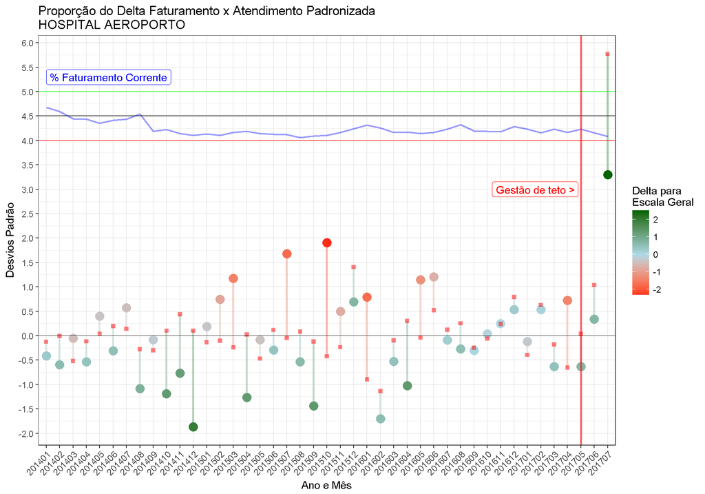

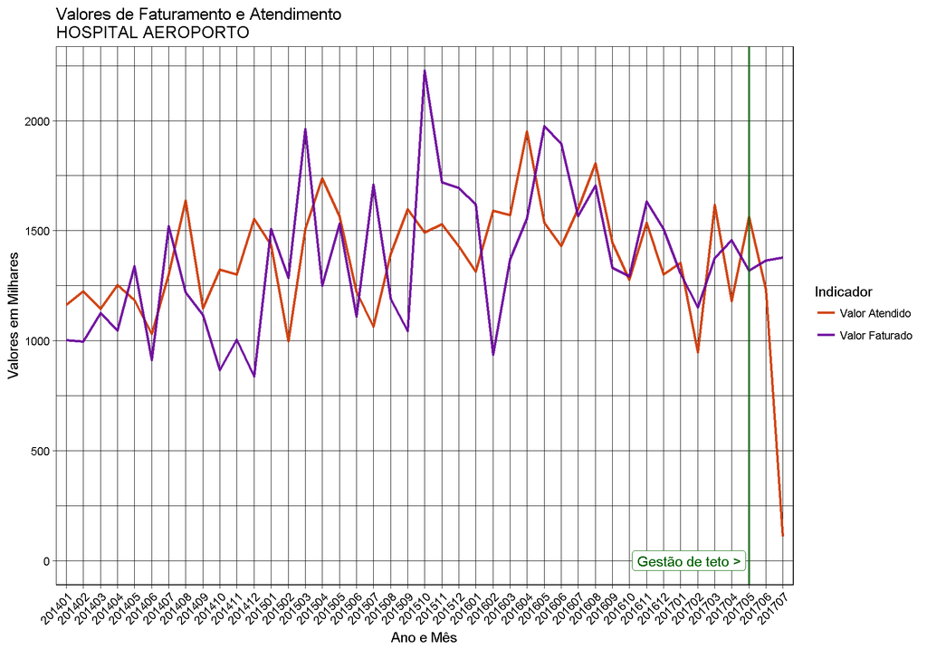

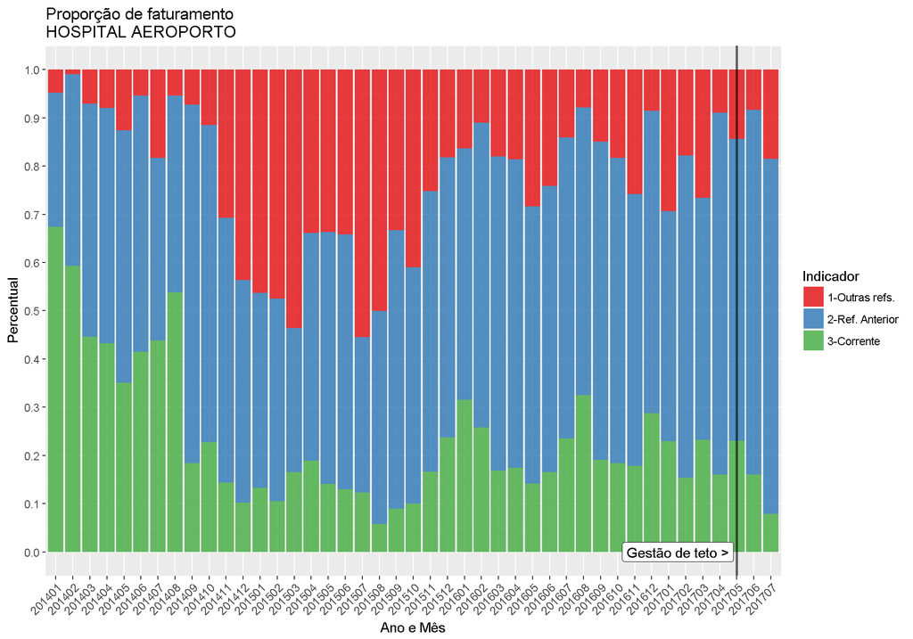

```
## [1] "HOSPITAL DAS CLINICAS DE ALAGOINHAS LTDA-HCA"
## [1] "------------------------------------------------------------------"
## [1] "Raking da seleção                :   2    "
## [1] "Raking de faturamento            :  21    "
## [1] "Raking de desvio médio absoluto  :  32    "
## [1] "Raking de % médio de f. corrente :  23    "
## [1] "Raking de % saldo de atendimento :  20    "
## [1] "------------------------------------------------------------------"
## [1] "Faturamento total                : 42158679.95         "
## [1] "Desvio médio absoluto            : 0.97                "
## [1] " % Médio de faturamento corrente : 25.89               "
## [1] " % Limite de acumulado 2017      : 10.59               "
## [1] "------------------------------------------------------------------"
##   |Ano|    |Saldo| |Faturamento Anual| |% Saldo sobre Faturamento|
## 1  2017 -834641.32             6629934                      -12.59
## 2  2016  -83417.39            12039723                       -0.69
## 3  2015  312982.51            11574776                        2.70
## 4  2014 -113419.45            11914007                       -0.95
## [1] "------------------------------------------------------------------"
```

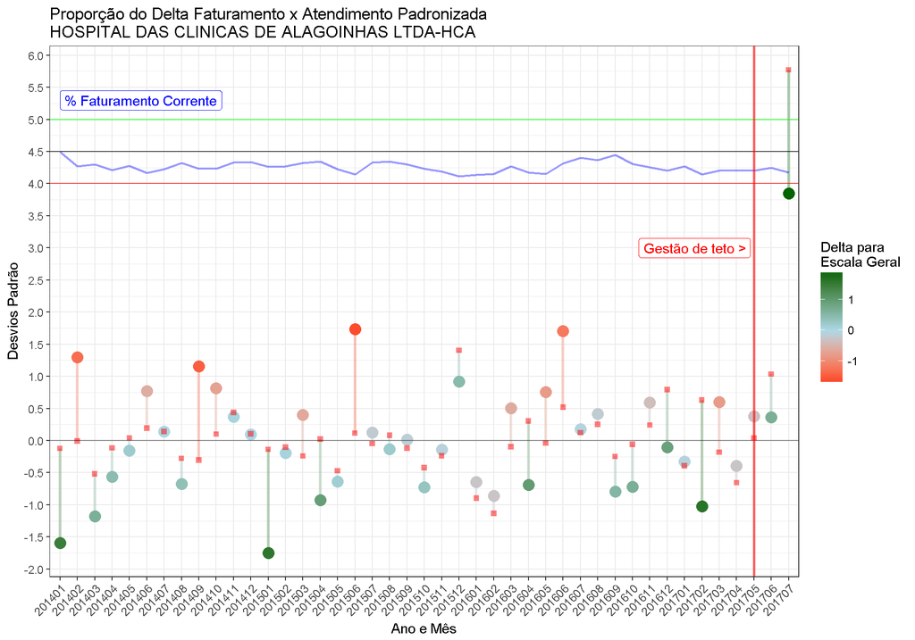

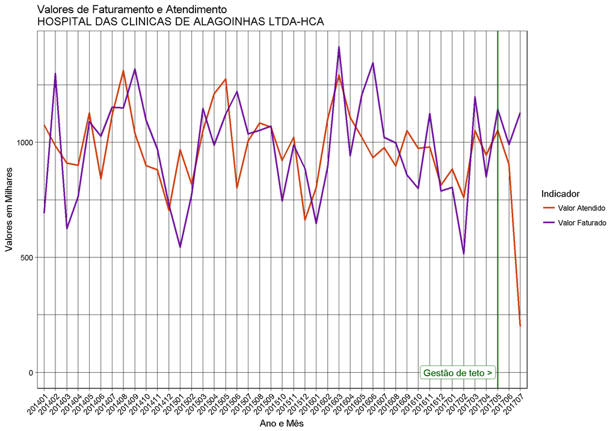

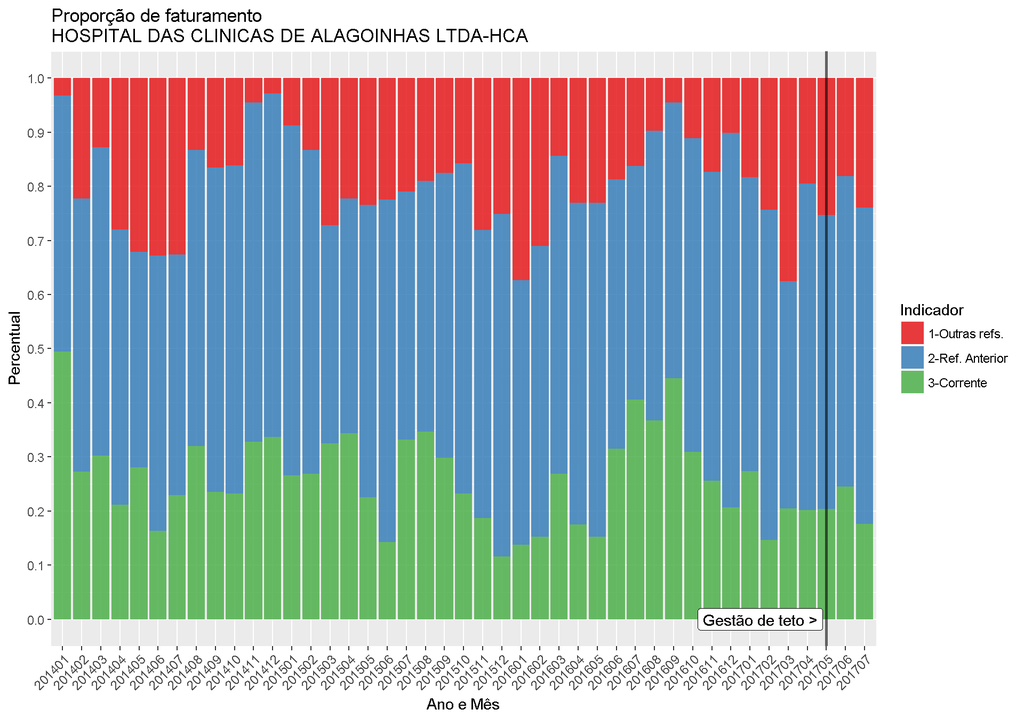

```
## [1] "HOSPITAL CALIXTO MIDLEJ FILHO"
## [1] "------------------------------------------------------------------"
## [1] "Raking da seleção                :   3    "
## [1] "Raking de faturamento            :  16    "
## [1] "Raking de desvio médio absoluto  :  82    "
## [1] "Raking de % médio de f. corrente :  20    "
## [1] "Raking de % saldo de atendimento :  22    "
## [1] "------------------------------------------------------------------"
## [1] "Faturamento total                : 54001694.62         "
## [1] "Desvio médio absoluto            : 0.79                "
## [1] " % Médio de faturamento corrente : 24.03               "
## [1] " % Limite de acumulado 2017      : 10.85               "
## [1] "------------------------------------------------------------------"
##   |Ano|    |Saldo| |Faturamento Anual| |% Saldo sobre Faturamento|
## 1  2017 -1093224.3             8919497                      -12.26
## 2  2016  -309097.2            16808404                       -1.84
## 3  2015   565018.8            13834102                        4.08
## 4  2014  -772975.8            13883806                       -5.57
## [1] "------------------------------------------------------------------"
```

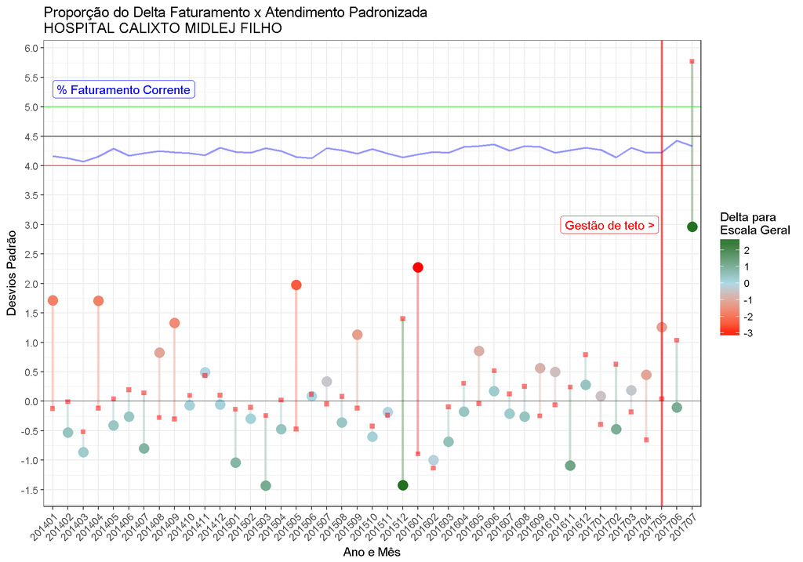

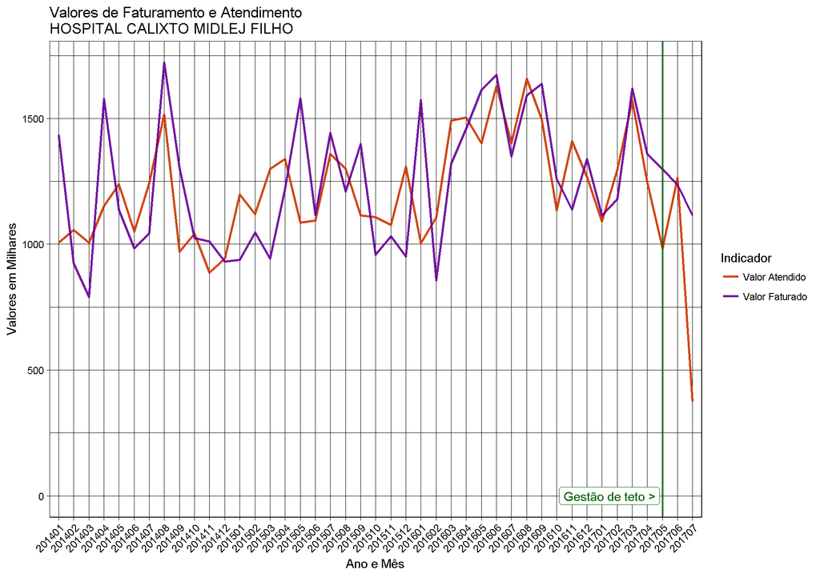

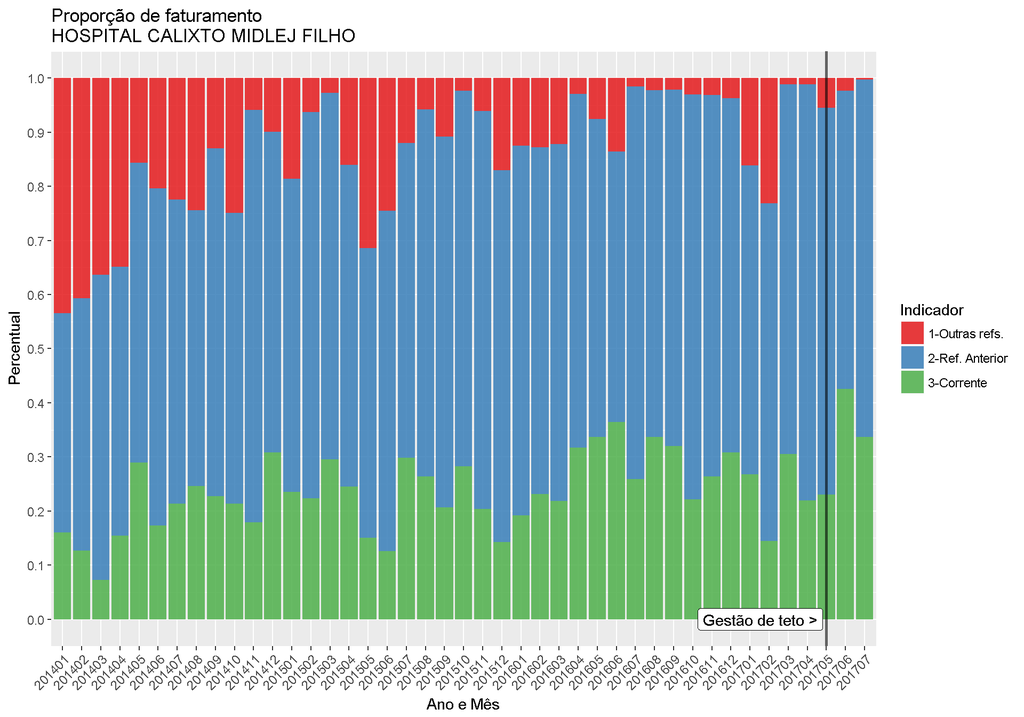

```
## [1] "HBA - HOSPITAL DA BAHIA"
## [1] "------------------------------------------------------------------"
## [1] "Raking da seleção                :   4    "
## [1] "Raking de faturamento            :   3    "
## [1] "Raking de desvio médio absoluto  :  85    "
## [1] "Raking de % médio de f. corrente :  35    "
## [1] "Raking de % saldo de atendimento :  26    "
## [1] "------------------------------------------------------------------"
## [1] "Faturamento total                : 345593634.18        "
## [1] "Desvio médio absoluto            : 0.78                "
## [1] " % Médio de faturamento corrente : 38.4                "
## [1] " % Limite de acumulado 2017      : 8.8                 "
## [1] "------------------------------------------------------------------"
##   |Ano|  |Saldo| |Faturamento Anual| |% Saldo sobre Faturamento|
## 1  2017 -7414049            63534378                      -11.67
## 2  2016   272632           109093579                        0.25
## 3  2015  1220526            99539508                        1.23
## 4  2014  2726674            66089625                        4.13
## [1] "------------------------------------------------------------------"
```

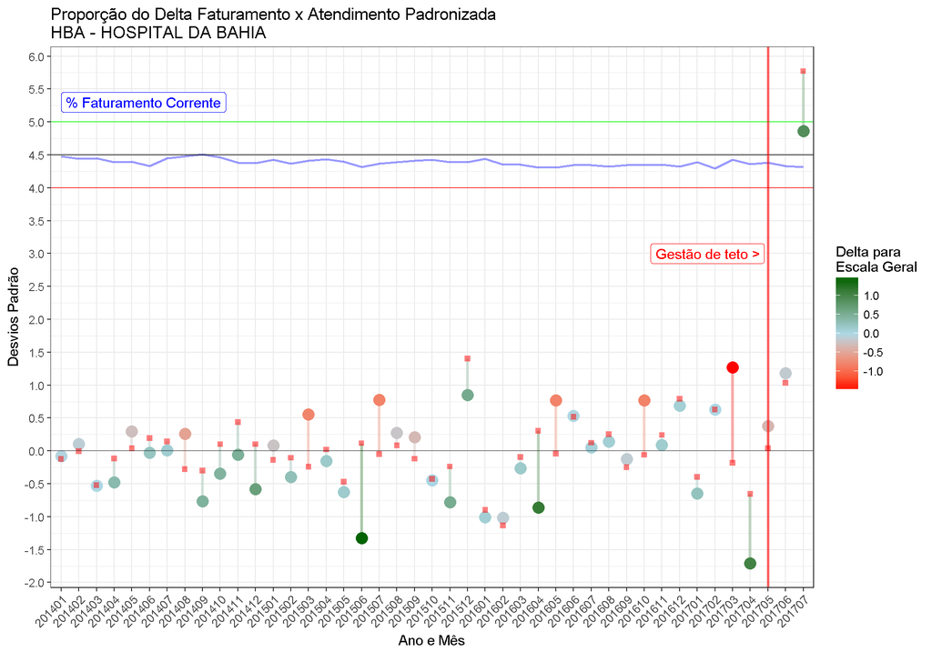

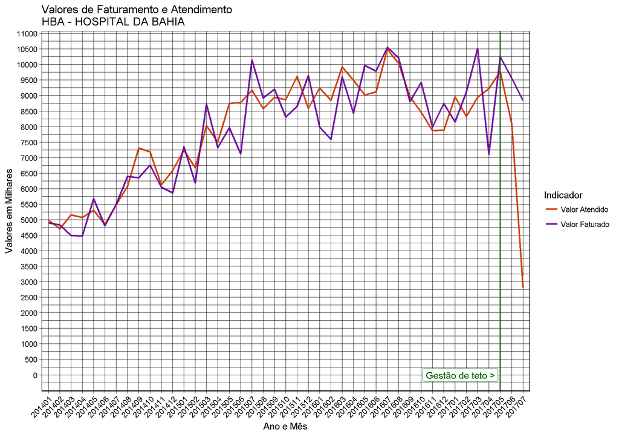

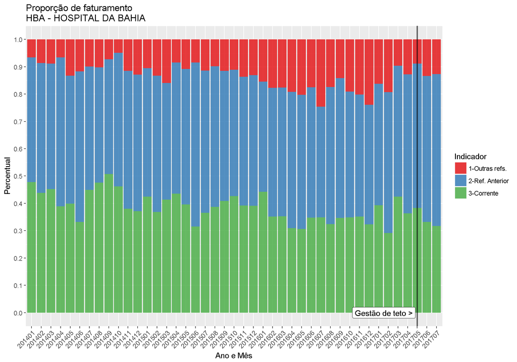

```
## [1] "COOPANEST"
## [1] "------------------------------------------------------------------"
## [1] "Raking da seleção                :   5    "
## [1] "Raking de faturamento            :   9    "
## [1] "Raking de desvio médio absoluto  :  93    "
## [1] "Raking de % médio de f. corrente :  27    "
## [1] "Raking de % saldo de atendimento :  29    "
## [1] "------------------------------------------------------------------"
## [1] "Faturamento total                : 83779285.34         "
## [1] "Desvio médio absoluto            : 0.75                "
## [1] " % Médio de faturamento corrente : 33.64               "
## [1] " % Limite de acumulado 2017      : 9.48                "
## [1] "------------------------------------------------------------------"
##   |Ano|    |Saldo| |Faturamento Anual| |% Saldo sobre Faturamento|
## 1  2017 -1928196.5            17359984                      -11.11
## 2  2016   470775.7            28121068                        1.67
## 3  2015   494690.2            21510656                        2.30
## 4  2014  -167187.7            16371923                       -1.02
## [1] "------------------------------------------------------------------"
```

[48 more figures not shown]

```r
FA.plot_rank <- FA.df_rank %>%
  filter(faturado > v.limite_min)

v.top <- ifelse(dim(FA.plot_rank)[1] < v.top, dim(FA.plot_rank)[1], v.top)

##----------------------------------------------------------------------------
# v.rank:
#   faturado.r
#   dma.r
#   dma.c.r
#   isa.r
##----------------------------------------------------------------------------

FA.plot_rank %<>%
  arrange(isa.r) %>%
  select(prestador) %>%
  '['(1:v.top,) %>%
  '[['(1)

for (i in seq_along(FA.plot_rank)) {
  f.tb_param(FA.plot_rank[i], i)
  f.gg_param(FA.plot_rank[i])
  f.gg_fa(FA.plot_rank[i])
}
```